# Analysis of NFL QB rating

## Preliminary Wrangling

I will be using the NFL QB career stats dataset for this analysis

```python
# import all packages and set plots to be embedded inline
import numpy as np
import pandas as pd
import matplotlib.pyplot as plt
import seaborn as sb; sb.set(style="ticks", color_codes=True)

%matplotlib inline
```

# Introduction

## I am a lifelong football fan and I am interested if there are any facotrs that can be used to predict QB success. I will be examining the career qb stats dataset from the NFL.

```python
career_stats_qb = pd.read_csv('Career_Stats_Passing.csv')
career_stats_qb.head()
```

|  | Player Id | Name | Position | Year | Team | Games Played | Passes Attempted | Passes Completed | Completion Percentage | Pass Attempts Per Game | ... | TD Passes | Percentage of TDs per Attempts | Ints | Int Rate | Longest Pass | Passes Longer than 20 Yards | Passes Longer than 40 Yards | Sacks | Sacked Yards Lost | Passer Rating |
| --- | --- | --- | --- | --- | --- | --- | --- | --- | --- | --- | --- | --- | --- | --- | --- | --- | --- | --- | --- | --- | --- |
| 0 | tomfarris/2513861 | Farris, Tom | NaN | 1948 | Chicago Rockets | 0 | -- | -- | -- | 0.0 | ... | -- | -- | -- | -- | -- | -- | -- | -- | -- | 0.0 |
| 1 | tomfarris/2513861 | Farris, Tom | NaN | 1947 | Chicago Bears | 9 | 2 | 0 | 0.0 | 0.2 | ... | 0 | 0.0 | 0 | 0.0 | -- | 0 | 0 | 0 | 0 | 39.6 |
| 2 | tomfarris/2513861 | Farris, Tom | NaN | 1946 | Chicago Bears | 11 | 21 | 8 | 38.1 | 1.9 | ... | 1 | 4.8 | 2 | 9.5 | -- | 0 | 0 | 0 | 0 | 31.5 |
| 3 | billdemory/2512778 | Demory, Bill | NaN | 1974 | New York Jets | 1 | -- | -- | -- | 0.0 | ... | -- | -- | -- | -- | -- | -- | -- | -- | -- | 0.0 |
| 4 | billdemory/2512778 | Demory, Bill | NaN | 1973 | New York Jets | 6 | 39 | 12 | 30.8 | 6.5 | ... | 2 | 5.1 | 8 | 20.5 | -- | 0 | 0 | 8 | 73 | 22.2 |

5 rows × 23 columns

```python
career_stats_qb = career_stats_qb.drop(['Player Id', 'Position', 'Year', 'Team'], axis=1)
```

```python
career_stats_qb.info()
```

```
<class 'pandas.core.frame.DataFrame'>
RangeIndex: 8525 entries, 0 to 8524
Data columns (total 19 columns):
 #   Column                          Non-Null Count  Dtype
---  ------                          --------------  -----
 0   Name                            8525 non-null   object
 1   Games Played                    8525 non-null   int64
 2   Passes Attempted                8525 non-null   object
 3   Passes Completed                8525 non-null   object
 4   Completion Percentage           8525 non-null   object
 5   Pass Attempts Per Game          8525 non-null   float64
 6   Passing Yards                   8525 non-null   object
 7   Passing Yards Per Attempt       8525 non-null   object
 8   Passing Yards Per Game          8525 non-null   object
 9   TD Passes                       8525 non-null   object
 10  Percentage of TDs per Attempts  8525 non-null   object
 11  Ints                            8525 non-null   object
 12  Int Rate                        8525 non-null   object
 13  Longest Pass                    8525 non-null   object
 14  Passes Longer than 20 Yards     8525 non-null   object
 15  Passes Longer than 40 Yards     8525 non-null   object
 16  Sacks                           8525 non-null   object
 17  Sacked Yards Lost               8525 non-null   object
 18  Passer Rating                   8525 non-null   float64
dtypes: float64(2), int64(1), object(16)
memory usage: 1.2+ MB
```

#### Right away we see that we have a problem with the data in the career_stats_qb dataframe. This dataframe contains data for everyone that has ever thrown a pass in an NFL game. Teams sometimes run trick plays where runningbacks or wide recievers throw pass, it also contains data for players that have had very short NFL careers for whatever reason and that could badly skew our data. I will need to set a cutoff point for passing attempts and remove any below that point. This will weed out the problematic data.

### What is the structure of your dataset?

> My dataset is made up of 8525 rows and 19 columns.

### What is/are the main feature(s) of interest in your dataset?

> I am really interested in looking at the effects of different factors on QB success. I really like how this dataset has data for so many different factors.

### What features in the dataset do you think will help support your investigation into your feature(s) of interest?

> I think that the way that the dataset has grouped all the different variables into columns will be of great help when it comes to analyzing the data.

#### Before I can begin to plot my data I must first fix a data quality issue. In the dataset if a player were to change teams his stats with his new team are listed seperately from his stats with his old team. To get an accurate comparison what I will have to do is break the stats down on a pergame basis.

```python
career_stats_qb = career_stats_qb.apply(pd.to_numeric, errors='ignore')
```

```python
career_stats_qb.info()
```

```
<class 'pandas.core.frame.DataFrame'>
RangeIndex: 8525 entries, 0 to 8524
Data columns (total 19 columns):
 #   Column                          Non-Null Count  Dtype
---  ------                          --------------  -----
 0   Name                            8525 non-null   object
 1   Games Played                    8525 non-null   int64
 2   Passes Attempted                8525 non-null   object
 3   Passes Completed                8525 non-null   object
 4   Completion Percentage           8525 non-null   object
 5   Pass Attempts Per Game          8525 non-null   float64
 6   Passing Yards                   8525 non-null   object
 7   Passing Yards Per Attempt       8525 non-null   object
 8   Passing Yards Per Game          8525 non-null   object
 9   TD Passes                       8525 non-null   object
 10  Percentage of TDs per Attempts  8525 non-null   object
 11  Ints                            8525 non-null   object
 12  Int Rate                        8525 non-null   object
 13  Longest Pass                    8525 non-null   object
 14  Passes Longer than 20 Yards     8525 non-null   object
 15  Passes Longer than 40 Yards     8525 non-null   object
 16  Sacks                           8525 non-null   object
 17  Sacked Yards Lost               8525 non-null   object
 18  Passer Rating                   8525 non-null   float64
dtypes: float64(2), int64(1), object(16)
memory usage: 1.2+ MB
```

```python
career_stats_qb['Ratings/game'] = career_stats_qb['Passer Rating']/career_stats_qb['Games Played']
```

```python
career_stats_qb.head()
```

|  | Name | Games Played | Passes Attempted | Passes Completed | Completion Percentage | Pass Attempts Per Game | Passing Yards | Passing Yards Per Attempt | Passing Yards Per Game | TD Passes | Percentage of TDs per Attempts | Ints | Int Rate | Longest Pass | Passes Longer than 20 Yards | Passes Longer than 40 Yards | Sacks | Sacked Yards Lost | Passer Rating | Ratings/game |
| --- | --- | --- | --- | --- | --- | --- | --- | --- | --- | --- | --- | --- | --- | --- | --- | --- | --- | --- | --- | --- |
| 0 | Farris, Tom | 0 | -- | -- | -- | 0.0 | -- | -- | -- | -- | -- | -- | -- | -- | -- | -- | -- | -- | 0.0 | NaN |
| 1 | Farris, Tom | 9 | 2 | 0 | 0.0 | 0.2 | 0 | 0.0 | 0.0 | 0 | 0.0 | 0 | 0.0 | -- | 0 | 0 | 0 | 0 | 39.6 | 4.400000 |
| 2 | Farris, Tom | 11 | 21 | 8 | 38.1 | 1.9 | 108 | 5.1 | 9.8 | 1 | 4.8 | 2 | 9.5 | -- | 0 | 0 | 0 | 0 | 31.5 | 2.863636 |
| 3 | Demory, Bill | 1 | -- | -- | -- | 0.0 | -- | -- | -- | -- | -- | -- | -- | -- | -- | -- | -- | -- | 0.0 | 0.000000 |
| 4 | Demory, Bill | 6 | 39 | 12 | 30.8 | 6.5 | 159 | 4.1 | 26.5 | 2 | 5.1 | 8 | 20.5 | -- | 0 | 0 | 8 | 73 | 22.2 | 3.700000 |

#### Another issue that has come up is qb's back in the day would just hand the ball off all game and so they would have 0 pass atempts for a game and also 0 passer rating. I need to remove all these values from the dataset. Before dropping these rows we have 8525 rows in our dataframe.

```python
career_stats_qb = career_stats_qb.dropna()
```

```python
career_stats_qb.info()
```

```
<class 'pandas.core.frame.DataFrame'>
Int64Index: 8007 entries, 1 to 8524
Data columns (total 20 columns):
 #   Column                          Non-Null Count  Dtype
---  ------                          --------------  -----
 0   Name                            8007 non-null   object
 1   Games Played                    8007 non-null   int64
 2   Passes Attempted                8007 non-null   object
 3   Passes Completed                8007 non-null   object
 4   Completion Percentage           8007 non-null   object
 5   Pass Attempts Per Game          8007 non-null   float64
 6   Passing Yards                   8007 non-null   object
 7   Passing Yards Per Attempt       8007 non-null   object
 8   Passing Yards Per Game          8007 non-null   object
 9   TD Passes                       8007 non-null   object
 10  Percentage of TDs per Attempts  8007 non-null   object
 11  Ints                            8007 non-null   object
 12  Int Rate                        8007 non-null   object
 13  Longest Pass                    8007 non-null   object
 14  Passes Longer than 20 Yards     8007 non-null   object
 15  Passes Longer than 40 Yards     8007 non-null   object
 16  Sacks                           8007 non-null   object
 17  Sacked Yards Lost               8007 non-null   object
 18  Passer Rating                   8007 non-null   float64
 19  Ratings/game                    8007 non-null   float64
dtypes: float64(3), int64(1), object(16)
memory usage: 1.3+ MB
```

#### Now we have 8007 rows.

```python
career_stats_qb = career_stats_qb.sort_values(by ='Ratings/game', ascending=False )
```

```python
career_stats_qb.head()
```

|  | Name | Games Played | Passes Attempted | Passes Completed | Completion Percentage | Pass Attempts Per Game | Passing Yards | Passing Yards Per Attempt | Passing Yards Per Game | TD Passes | Percentage of TDs per Attempts | Ints | Int Rate | Longest Pass | Passes Longer than 20 Yards | Passes Longer than 40 Yards | Sacks | Sacked Yards Lost | Passer Rating | Ratings/game |
| --- | --- | --- | --- | --- | --- | --- | --- | --- | --- | --- | --- | --- | --- | --- | --- | --- | --- | --- | --- | --- |
| 5801 | Nassib, Ryan | 1 | 5 | 5 | 100.0 | 5.0 | 68 | 13.6 | 68.0 | 1 | 20.0 | 0 | 0.0 | 25T | 1 | 0 | 0 | 0 | 158.3 | 158.3 |
| 3675 | Bell, Kerwin | 1 | 5 | 5 | 100.0 | 5.0 | 75 | 15.0 | 75.0 | 1 | 20.0 | 0 | 0.0 | 30 | 2 | 0 | 0 | 0 | 158.3 | 158.3 |
| 2390 | Hill, Shaun | 1 | 13 | 10 | 76.9 | 13.0 | 172 | 13.2 | 172.0 | 2 | 15.4 | 0 | 0.0 | 46T | 4 | 1 | 0 | 0 | 157.9 | 157.9 |
| 5856 | McBride, Jack | 1 | 3 | 3 | 100.0 | 3.0 | 37 | 12.3 | 37.0 | 1 | 33.3 | 0 | 0.0 | -- | 0 | 0 | 0 | 0 | 157.6 | 157.6 |
| 3508 | Garrett, Jason | 1 | 5 | 4 | 80.0 | 5.0 | 46 | 9.2 | 46.0 | 1 | 20.0 | 0 | 0.0 | 24 | 1 | 0 | 0 | 0 | 144.6 | 144.6 |

```python
career_stats_qb.rename(columns = {'Passes Attempted':'Passes_Attempted', 'Games Played' : 'Games_Played', 'Passes Completed' : 'Passes_Completed', 'Completion Percentage' : 'Completion_Percentage', 'Pass Attempts Per Game' : 'Pass_Attempts_Per_Game', 'Passing Yards' : 'Passing_Yards', 'Passing Yards Per Attempt' : 'Passing_Yards_Per_Attempt', 'Passing Yards Per Game' : 'Passing_Yards_Per_Game', 'TD Passes' : 'TD_Passes', 'Percentage of TDs per Attempts' : 'Percentage_of_TDs_per_Attempts', 'Int Rate' : 'Int_Rate', 'Longest Pass' : 'Longest_Pass', 'Passes Longer than 20 Yards' : 'Passes_Longer_than_20_Yards', 'Passes Longer than 40 Yards' : 'Passes_Longer_than_40_Yards', 'Sacked Yards Lost' : 'Sacked_Yards_Lost', 'Passer Rating' : 'Passer_Rating'}, inplace = True)
```

```python
career_stats_qb.info()
```

```
<class 'pandas.core.frame.DataFrame'>
Int64Index: 8007 entries, 5801 to 8524
Data columns (total 20 columns):
 #   Column                          Non-Null Count  Dtype
---  ------                          --------------  -----
 0   Name                            8007 non-null   object
 1   Games_Played                    8007 non-null   int64
 2   Passes_Attempted                8007 non-null   object
 3   Passes_Completed                8007 non-null   object
 4   Completion_Percentage           8007 non-null   object
 5   Pass_Attempts_Per_Game          8007 non-null   float64
 6   Passing_Yards                   8007 non-null   object
 7   Passing_Yards_Per_Attempt       8007 non-null   object
 8   Passing_Yards_Per_Game          8007 non-null   object
 9   TD_Passes                       8007 non-null   object
 10  Percentage_of_TDs_per_Attempts  8007 non-null   object
 11  Ints                            8007 non-null   object
 12  Int_Rate                        8007 non-null   object
 13  Longest_Pass                    8007 non-null   object
 14  Passes_Longer_than_20_Yards     8007 non-null   object
 15  Passes_Longer_than_40_Yards     8007 non-null   object
 16  Sacks                           8007 non-null   object
 17  Sacked_Yards_Lost               8007 non-null   object
 18  Passer_Rating                   8007 non-null   float64
 19  Ratings/game                    8007 non-null   float64
dtypes: float64(3), int64(1), object(16)
memory usage: 1.3+ MB
```

#### We can see from looking at the above that there are numerous values equal to -- in our dataframe. We will need to remove those before we can proceed.

```python
career_stats_qb = career_stats_qb.replace({'--': 0}, regex=True)
```

```python
career_stats_qb.tail(10)
```

|  | Name | Games_Played | Passes_Attempted | Passes_Completed | Completion_Percentage | Pass_Attempts_Per_Game | Passing_Yards | Passing_Yards_Per_Attempt | Passing_Yards_Per_Game | TD_Passes | Percentage_of_TDs_per_Attempts | Ints | Int_Rate | Longest_Pass | Passes_Longer_than_20_Yards | Passes_Longer_than_40_Yards | Sacks | Sacked_Yards_Lost | Passer_Rating | Ratings/game |
| --- | --- | --- | --- | --- | --- | --- | --- | --- | --- | --- | --- | --- | --- | --- | --- | --- | --- | --- | --- | --- |
| 3818 | Camarillo, Rich | 16 | 0 | 0 | 0 | 0.0 | 0 | 0 | 0 | 0 | 0 | 0 | 0 | 0 | 0 | 0 | 0 | 0 | 0.0 | 0.0 |
| 3817 | Camarillo, Rich | 7 | 0 | 0 | 0 | 0.0 | 0 | 0 | 0 | 0 | 0 | 0 | 0 | 0 | 0 | 0 | 0 | 0 | 0.0 | 0.0 |
| 3816 | Camarillo, Rich | 16 | 0 | 0 | 0 | 0.0 | 0 | 0 | 0 | 0 | 0 | 0 | 0 | 0 | 0 | 0 | 0 | 0 | 0.0 | 0.0 |
| 3815 | Camarillo, Rich | 16 | 0 | 0 | 0 | 0.0 | 0 | 0 | 0 | 0 | 0 | 0 | 0 | 0 | 0 | 0 | 0 | 0 | 0.0 | 0.0 |
| 3814 | Camarillo, Rich | 12 | 0 | 0 | 0 | 0.0 | 0 | 0 | 0 | 0 | 0 | 0 | 0 | 0 | 0 | 0 | 0 | 0 | 0.0 | 0.0 |
| 3813 | Camarillo, Rich | 9 | 0 | 0 | 0 | 0.0 | 0 | 0 | 0 | 0 | 0 | 0 | 0 | 0 | 0 | 0 | 0 | 0 | 0.0 | 0.0 |
| 3811 | Camarillo, Rich | 16 | 0 | 0 | 0 | 0.0 | 0 | 0 | 0 | 0 | 0 | 0 | 0 | 0 | 0 | 0 | 0 | 0 | 0.0 | 0.0 |
| 3809 | Camarillo, Rich | 15 | 0 | 0 | 0 | 0.0 | 0 | 0 | 0 | 0 | 0 | 0 | 0 | 0 | 0 | 0 | 0 | 0 | 0.0 | 0.0 |
| 3808 | Camarillo, Rich | 16 | 0 | 0 | 0 | 0.0 | 0 | 0 | 0 | 0 | 0 | 0 | 0 | 0 | 0 | 0 | 0 | 0 | 0.0 | 0.0 |
| 8524 | Anderson, Bill | 12 | 0 | 0 | 0 | 0.0 | 0 | 0 | 0 | 0 | 0 | 0 | 0 | 0 | 0 | 0 | 0 | 0 | 0.0 | 0.0 |

#### We see in the above step that there are still many 0 entries in our dataset. I am looking for QB that had long careers because I am hoping to find factors that might be predictive of QB success. As such I will remove any rows with a 0 in it.

```python
career_stats_qb = career_stats_qb[career_stats_qb.loc[:]!=0].dropna()
```

```python
career_stats_qb.info()
```

```
<class 'pandas.core.frame.DataFrame'>
Int64Index: 2382 entries, 5801 to 666
Data columns (total 20 columns):
 #   Column                          Non-Null Count  Dtype
---  ------                          --------------  -----
 0   Name                            2382 non-null   object
 1   Games_Played                    2382 non-null   int64
 2   Passes_Attempted                2382 non-null   object
 3   Passes_Completed                2382 non-null   object
 4   Completion_Percentage           2382 non-null   object
 5   Pass_Attempts_Per_Game          2382 non-null   float64
 6   Passing_Yards                   2382 non-null   object
 7   Passing_Yards_Per_Attempt       2382 non-null   object
 8   Passing_Yards_Per_Game          2382 non-null   object
 9   TD_Passes                       2382 non-null   object
 10  Percentage_of_TDs_per_Attempts  2382 non-null   object
 11  Ints                            2382 non-null   object
 12  Int_Rate                        2382 non-null   object
 13  Longest_Pass                    2382 non-null   object
 14  Passes_Longer_than_20_Yards     2382 non-null   object
 15  Passes_Longer_than_40_Yards     2382 non-null   object
 16  Sacks                           2382 non-null   object
 17  Sacked_Yards_Lost               2382 non-null   object
 18  Passer_Rating                   2382 non-null   float64
 19  Ratings/game                    2382 non-null   float64
dtypes: float64(3), int64(1), object(16)
memory usage: 390.8+ KB
```

#### Even though our dataframe is complied of all numbers, except for the name column, multiple columns are listing their dtype as object. We need to fix that.

```python
career_stats_qb = career_stats_qb.apply(pd.to_numeric, errors='ignore')
```

```python
career_stats_qb.info()
```

```
<class 'pandas.core.frame.DataFrame'>
Int64Index: 2382 entries, 5801 to 666
Data columns (total 20 columns):
 #   Column                          Non-Null Count  Dtype
---  ------                          --------------  -----
 0   Name                            2382 non-null   object
 1   Games_Played                    2382 non-null   int64
 2   Passes_Attempted                2382 non-null   int64
 3   Passes_Completed                2382 non-null   int64
 4   Completion_Percentage           2382 non-null   float64
 5   Pass_Attempts_Per_Game          2382 non-null   float64
 6   Passing_Yards                   2382 non-null   object
 7   Passing_Yards_Per_Attempt       2382 non-null   float64
 8   Passing_Yards_Per_Game          2382 non-null   float64
 9   TD_Passes                       2382 non-null   int64
 10  Percentage_of_TDs_per_Attempts  2382 non-null   float64
 11  Ints                            2382 non-null   int64
 12  Int_Rate                        2382 non-null   float64
 13  Longest_Pass                    2382 non-null   object
 14  Passes_Longer_than_20_Yards     2382 non-null   int64
 15  Passes_Longer_than_40_Yards     2382 non-null   int64
 16  Sacks                           2382 non-null   int64
 17  Sacked_Yards_Lost               2382 non-null   int64
 18  Passer_Rating                   2382 non-null   float64
 19  Ratings/game                    2382 non-null   float64
dtypes: float64(8), int64(9), object(3)
memory usage: 390.8+ KB
```

#### That worked for most of the columns but Passing yards and longest pass are still showing up as objects and so I will have to change them now.

```python
career_stats_qb[['Passing_Yards', 'Longest_Pass']] = career_stats_qb[['Passing_Yards', 'Longest_Pass']].apply(pd.to_numeric, errors='coerce')
```

```python
career_stats_qb.info()
```

```
<class 'pandas.core.frame.DataFrame'>
Int64Index: 2382 entries, 5801 to 666
Data columns (total 20 columns):
 #   Column                          Non-Null Count  Dtype
---  ------                          --------------  -----
 0   Name                            2382 non-null   object
 1   Games_Played                    2382 non-null   int64
 2   Passes_Attempted                2382 non-null   int64
 3   Passes_Completed                2382 non-null   int64
 4   Completion_Percentage           2382 non-null   float64
 5   Pass_Attempts_Per_Game          2382 non-null   float64
 6   Passing_Yards                   1450 non-null   float64
 7   Passing_Yards_Per_Attempt       2382 non-null   float64
 8   Passing_Yards_Per_Game          2382 non-null   float64
 9   TD_Passes                       2382 non-null   int64
 10  Percentage_of_TDs_per_Attempts  2382 non-null   float64
 11  Ints                            2382 non-null   int64
 12  Int_Rate                        2382 non-null   float64
 13  Longest_Pass                    1452 non-null   float64
 14  Passes_Longer_than_20_Yards     2382 non-null   int64
 15  Passes_Longer_than_40_Yards     2382 non-null   int64
 16  Sacks                           2382 non-null   int64
 17  Sacked_Yards_Lost               2382 non-null   int64
 18  Passer_Rating                   2382 non-null   float64
 19  Ratings/game                    2382 non-null   float64
dtypes: float64(10), int64(9), object(1)
memory usage: 390.8+ KB
```

#### From looking at my data I see a lot of players who only played a handful of games in their acreers, or only attempted a few passes. I need to figure out a reasonable cutoff for both so I can remove players who are not contributing to what I am interested in studying. I also need to look and see which stats seem to have the biggest effect on QB ratings so I will plot QB rating versus each of my variables now to get a sense of any connections.

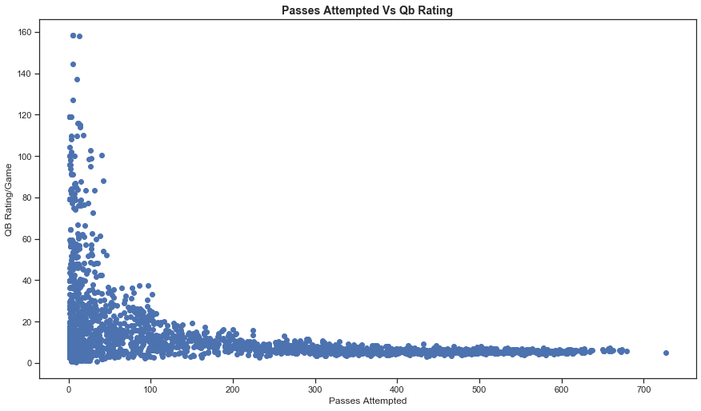

```python
# Scatterplot -  Ratings/game vs Passes Attempted

plt.figure(figsize=[14.70, 8.27])
plt.scatter(career_stats_qb['Passes_Attempted'], career_stats_qb['Ratings/game']);
plt.xlabel("Passes Attempted")
plt.ylabel("QB Rating/Game");
plt.title("Passes Attempted Vs QB Rating".title(), fontsize = 14, weight = "bold" );
```

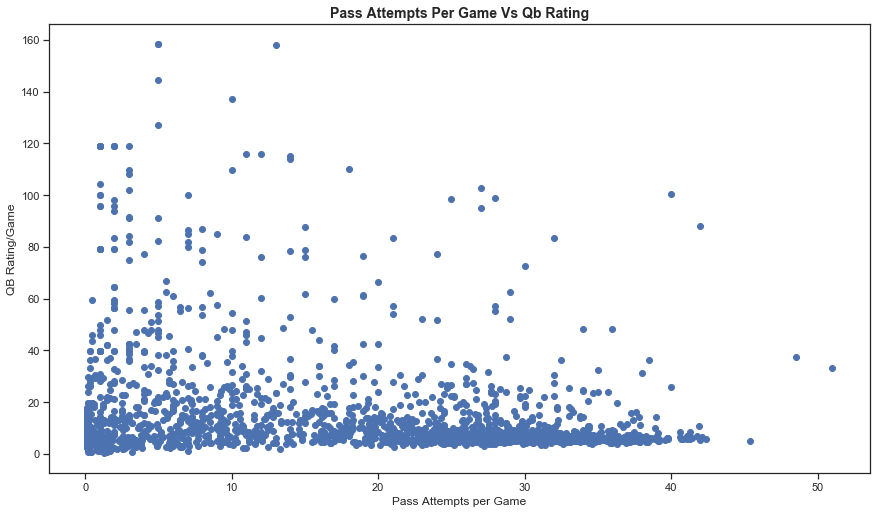

```python
# Scatterplot - Ratings/game vs Pass Attempts/game

plt.figure(figsize=[14.70, 8.27])
plt.scatter(career_stats_qb['Pass_Attempts_Per_Game'], career_stats_qb['Ratings/game']);
plt.xlabel("Pass Attempts per Game")
plt.ylabel("QB Rating/Game");
plt.title("Pass Attempts per Game Vs QB Rating".title(), fontsize = 14, weight = "bold" );
```

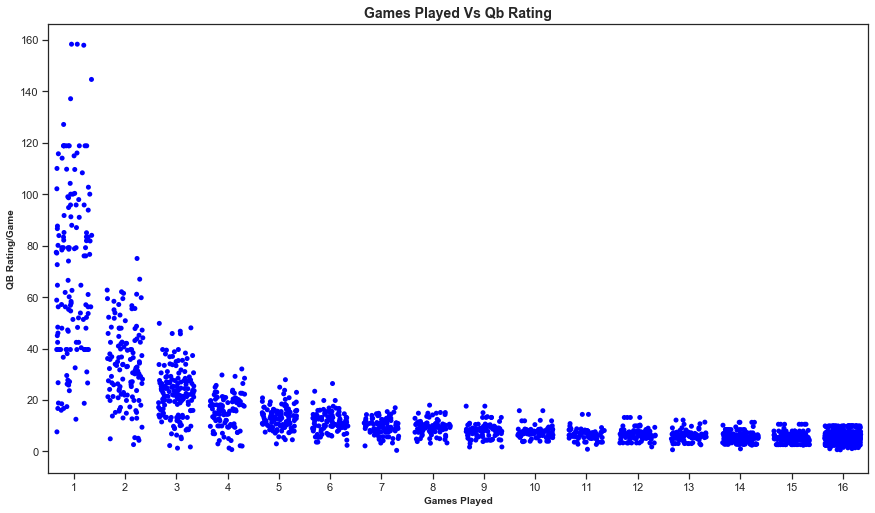

```python
# Scatterplot - Ratings/game vs Games played

plt.figure(figsize=[14.70, 8.27])
sb.stripplot(career_stats_qb['Games_Played'],
            career_stats_qb['Ratings/game'],
            jitter = 0.35, color = "blue");
plt.xlabel("Games Played", fontsize = 10, weight = "bold");
plt.ylabel("QB Rating/Game", fontsize = 10, weight = "bold");
plt.title("Games Played Vs QB Rating".title(), fontsize = 14, weight = "bold" );
```

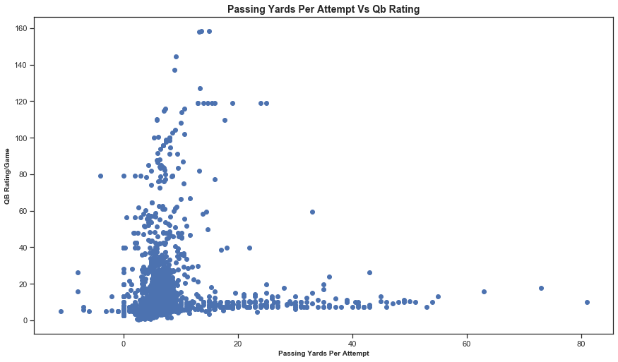

```python
# Scatterplot Ratings per game vs Passing Yards per Attempt

plt.figure(figsize=[14.70, 8.27])
plt.scatter(career_stats_qb['Passing_Yards_Per_Attempt'],
            career_stats_qb['Ratings/game']);
plt.xlabel("Passing Yards Per Attempt", fontsize = 10, weight = "bold");
plt.ylabel("QB Rating/Game", fontsize = 10, weight = "bold");
plt.title("Passing Yards per Attempt Vs QB Rating".title(), fontsize = 14, weight = "bold" );
```

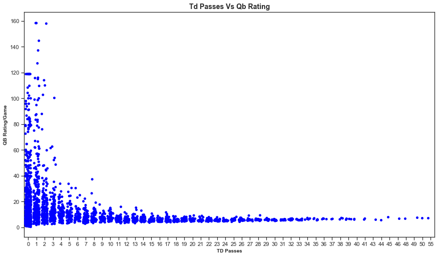

```python
# Scatterplot - Ratings/game vs TD Passes

plt.figure(figsize=[14.70, 8.27])
sb.stripplot(career_stats_qb['TD_Passes'],
            career_stats_qb['Ratings/game'],
            jitter = 0.35, color = "blue");
plt.xlabel("TD Passes", fontsize = 10, weight = "bold");
plt.ylabel("QB Rating/Game", fontsize = 10, weight = "bold");
plt.title("TD Passes Vs QB Rating".title(), fontsize = 14, weight = "bold" );
```

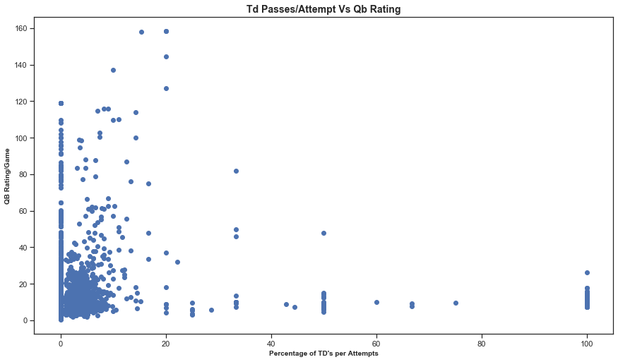

```python
# Scatterplot Ratings per game vs TD Passes/Attempt

plt.figure(figsize=[14.70, 8.27])
plt.scatter(career_stats_qb['Percentage_of_TDs_per_Attempts'],
            career_stats_qb['Ratings/game']);
plt.xlabel("Percentage of TD's per Attempts", fontsize = 10, weight = "bold");
plt.ylabel("QB Rating/Game", fontsize = 10, weight = "bold");
plt.title("TD Passes/Attempt Vs QB Rating".title(), fontsize = 14, weight = "bold" );
```

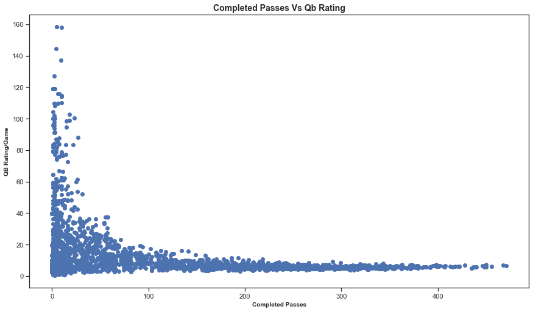

```python
# Scatterplot Ratings per game vs Passes Completed

plt.figure(figsize=[14.70, 8.27])
plt.scatter(career_stats_qb['Passes_Completed'],
            career_stats_qb['Ratings/game']);
plt.xlabel("Completed Passes", fontsize = 10, weight = "bold");
plt.ylabel("QB Rating/Game", fontsize = 10, weight = "bold");
plt.title("Completed Passes Vs QB Rating".title(), fontsize = 14, weight = "bold" );
```

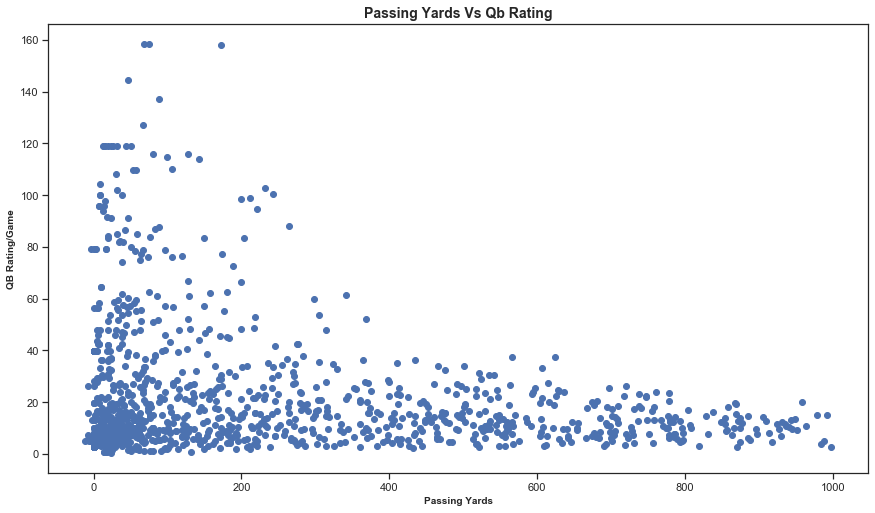

```python
# Scatterplot Ratings per game vs Passing Yards

plt.figure(figsize=[14.70, 8.27])
plt.scatter(career_stats_qb['Passing_Yards'],
            career_stats_qb['Ratings/game']);
plt.xlabel("Passing Yards", fontsize = 10, weight = "bold");
plt.ylabel("QB Rating/Game", fontsize = 10, weight = "bold");
plt.title("Passing Yards Vs QB Rating".title(), fontsize = 14, weight = "bold" );
```

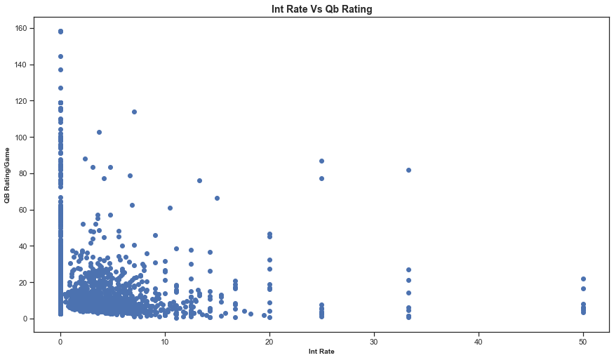

```python
# Scatterplot Ratings per game vs Int Rate

plt.figure(figsize=[14.70, 8.27])
plt.scatter(career_stats_qb['Int_Rate'],
            career_stats_qb['Ratings/game']);
plt.xlabel("Int Rate", fontsize = 10, weight = "bold");
plt.ylabel("QB Rating/Game", fontsize = 10, weight = "bold");
plt.title("Int Rate Vs QB Rating".title(), fontsize = 14, weight = "bold" );
```

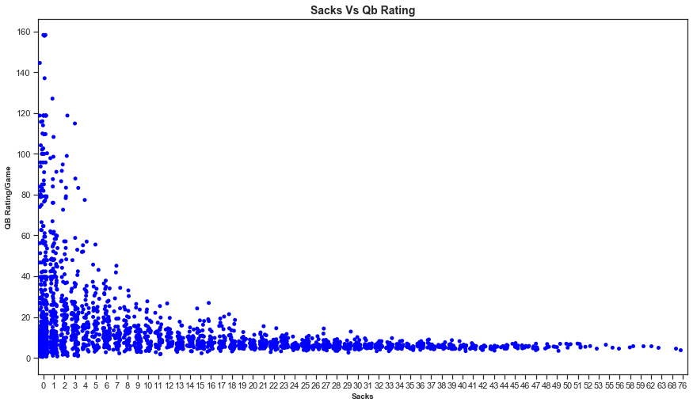

```python
# Scatterplot Ratings per game vs Sacks

plt.figure(figsize=[14.70, 8.27])
sb.stripplot(career_stats_qb['Sacks'],
            career_stats_qb['Ratings/game'],
            jitter = 0.35, color = "blue");
plt.xlabel("Sacks", fontsize = 10, weight = "bold");
plt.ylabel("QB Rating/Game", fontsize = 10, weight = "bold");
plt.title("Sacks Vs QB Rating".title(), fontsize = 14, weight = "bold" );
```

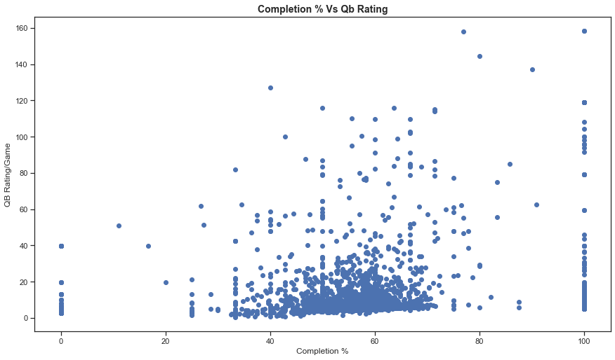

```python
# Scatterplot -  Ratings/game vs Completion %

plt.figure(figsize=[14.70, 8.27])
plt.scatter(career_stats_qb['Completion_Percentage'], career_stats_qb['Ratings/game']);
plt.xlabel("Completion %")
plt.ylabel("QB Rating/Game");
plt.title("Completion % Vs QB Rating".title(), fontsize = 14, weight = "bold" );
```

#### Looking at the graph of passes attempted we see that the data spikes to the left of 100 passes attempted, and for games played we see that the data starts to increase to the left of 10. Those will be our cutoffs going forward.

```python
career_stats_qb_clean = career_stats_qb.query('Passes_Attempted > 100 and Games_Played > 10 and Completion_Percentage < 70.0')
```

```python
career_stats_qb_clean.info()
```

```
<class 'pandas.core.frame.DataFrame'>
Int64Index: 729 entries, 2577 to 2359
Data columns (total 20 columns):
 #   Column                          Non-Null Count  Dtype
---  ------                          --------------  -----
 0   Name                            729 non-null    object
 1   Games_Played                    729 non-null    int64
 2   Passes_Attempted                729 non-null    int64
 3   Passes_Completed                729 non-null    int64
 4   Completion_Percentage           729 non-null    float64
 5   Pass_Attempts_Per_Game          729 non-null    float64
 6   Passing_Yards                   19 non-null     float64
 7   Passing_Yards_Per_Attempt       729 non-null    float64
 8   Passing_Yards_Per_Game          729 non-null    float64
 9   TD_Passes                       729 non-null    int64
 10  Percentage_of_TDs_per_Attempts  729 non-null    float64
 11  Ints                            729 non-null    int64
 12  Int_Rate                        729 non-null    float64
 13  Longest_Pass                    250 non-null    float64
 14  Passes_Longer_than_20_Yards     729 non-null    int64
 15  Passes_Longer_than_40_Yards     729 non-null    int64
 16  Sacks                           729 non-null    int64
 17  Sacked_Yards_Lost               729 non-null    int64
 18  Passer_Rating                   729 non-null    float64
 19  Ratings/game                    729 non-null    float64
dtypes: float64(10), int64(9), object(1)
memory usage: 119.6+ KB
```

#### Looking at the info for our new dataframe we see that their is a problem with the passing yards column so we will drop that.

```python
career_stats_qb_clean = career_stats_qb_clean.drop(['Passing_Yards'], axis = 1)
```

```python
career_stats_qb_clean.info()
```

```
<class 'pandas.core.frame.DataFrame'>
Int64Index: 729 entries, 2577 to 2359
Data columns (total 19 columns):
 #   Column                          Non-Null Count  Dtype
---  ------                          --------------  -----
 0   Name                            729 non-null    object
 1   Games_Played                    729 non-null    int64
 2   Passes_Attempted                729 non-null    int64
 3   Passes_Completed                729 non-null    int64
 4   Completion_Percentage           729 non-null    float64
 5   Pass_Attempts_Per_Game          729 non-null    float64
 6   Passing_Yards_Per_Attempt       729 non-null    float64
 7   Passing_Yards_Per_Game          729 non-null    float64
 8   TD_Passes                       729 non-null    int64
 9   Percentage_of_TDs_per_Attempts  729 non-null    float64
 10  Ints                            729 non-null    int64
 11  Int_Rate                        729 non-null    float64
 12  Longest_Pass                    250 non-null    float64
 13  Passes_Longer_than_20_Yards     729 non-null    int64
 14  Passes_Longer_than_40_Yards     729 non-null    int64
 15  Sacks                           729 non-null    int64
 16  Sacked_Yards_Lost               729 non-null    int64
 17  Passer_Rating                   729 non-null    float64
 18  Ratings/game                    729 non-null    float64
dtypes: float64(9), int64(9), object(1)
memory usage: 113.9+ KB
```

#### Now that our dataframe is fully clean we are ready to dive into analysing the data. Our first step will be to redo our plots of interest and see if we can get more out of them now.

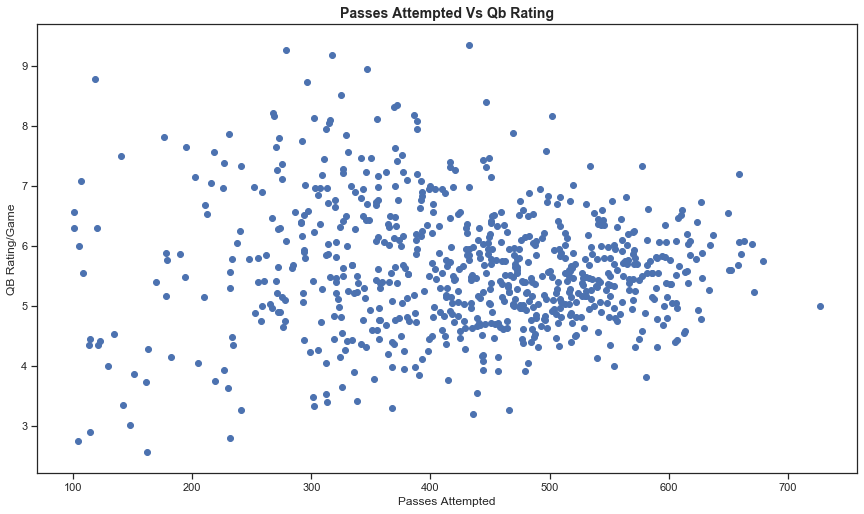

```python
# Scatterplot -  Ratings/game vs Passes Attempted

plt.figure(figsize=[14.70, 8.27])
plt.scatter(career_stats_qb_clean['Passes_Attempted'], career_stats_qb_clean['Ratings/game']);
plt.xlabel("Passes Attempted")
plt.ylabel("QB Rating/Game");
plt.title("Passes Attempted Vs QB Rating".title(), fontsize = 14, weight = "bold" );
```

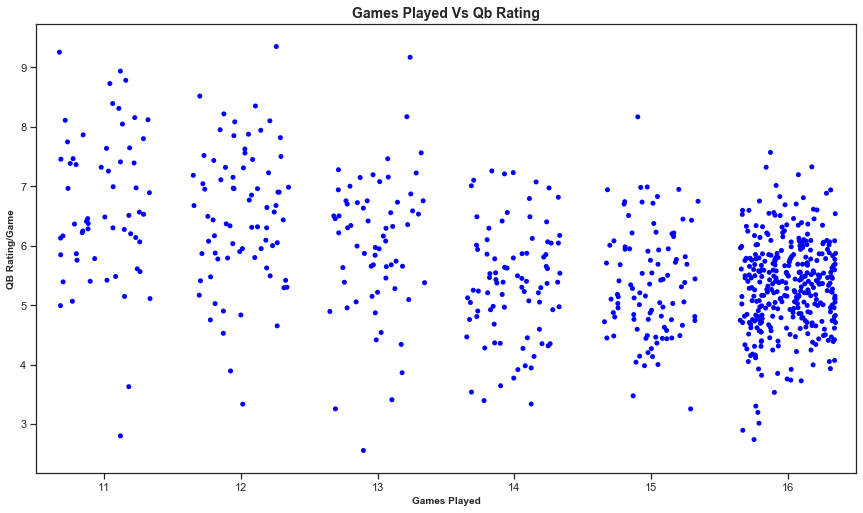

```python
# Scatterplot - Ratings/game vs Games played

plt.figure(figsize=[14.70, 8.27])
sb.stripplot(career_stats_qb_clean['Games_Played'],
            career_stats_qb_clean['Ratings/game'],
            jitter = 0.35, color = "blue");
plt.xlabel("Games Played", fontsize = 10, weight = "bold");
plt.ylabel("QB Rating/Game", fontsize = 10, weight = "bold");
plt.title("Games Played Vs QB Rating".title(), fontsize = 14, weight = "bold" );
```

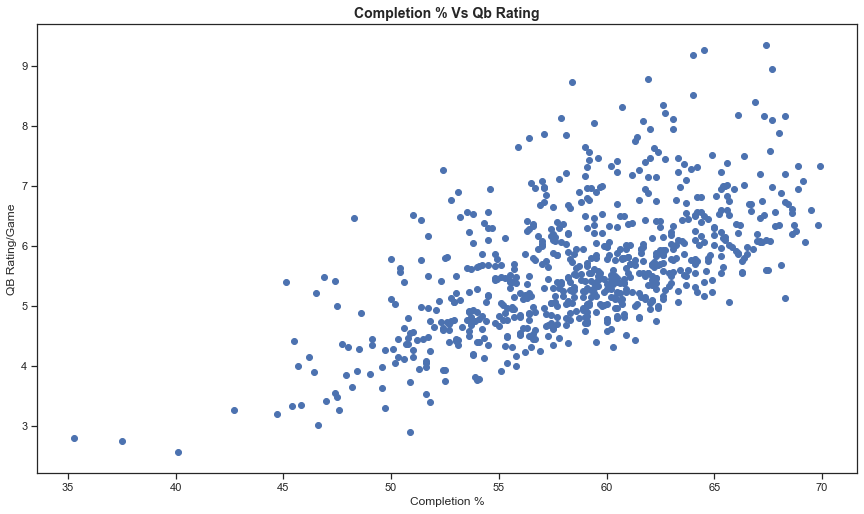

```python
# Scatterplot -  Ratings/game vs Completion %

plt.figure(figsize=[14.70, 8.27])
plt.scatter(career_stats_qb_clean['Completion_Percentage'], career_stats_qb_clean['Ratings/game']);
plt.xlabel("Completion %")
plt.ylabel("QB Rating/Game");
plt.title("Completion % Vs QB Rating".title(), fontsize = 14, weight = "bold" );
```

### Discuss the distribution(s) of your variable(s) of interest. Were there any unusual points? Did you need to perform any transformations?

The variable that I was interested in, passer rating per game was very evenly distributed. Values ranged from over 9 all the way down to 3. The majority of values were clustered in the middle as would be expected. The vbalue that stood out the most to me was that there has only been one QB to attempt over 700 passes in a season and his qb rating per game was actually on the lower end. So it seems his team kept having him pass even though he was not being successful with those passes.

### Of the features you investigated, were there any unusual distributions? Did you perform any operations on the data to tidy, adjust, or change the form of the data? If so, why did you do this?

I preformed several operations to tidy my data. I did this so that I could get it into a state where it would be easy to examine the variables that I was interested in. I also tidy the data so that I could cut down on the amount of data that I had to sift through. The 2nd version of the plots that I made where much easier to read thanks to the tiding work that I did.

## Bivariate Exploration

#### The first thing I want to look at is how all of the variables are related to each other. Before I can do that I need to trim some columns from the dat set. I will be removing all columns that are basically duplicates of other columns. I will also drop columns that are not the direct result of the QB himself.

```python
career_stats_qb_clean_new = career_stats_qb_clean.drop(['Name', 'Passes_Completed','Pass_Attempts_Per_Game', 'Passing_Yards_Per_Game', 'Percentage_of_TDs_per_Attempts', 'Int_Rate', 'Longest_Pass', 'Passes_Longer_than_20_Yards', 'Passes_Longer_than_40_Yards', 'Sacks', 'Sacked_Yards_Lost', 'Passer_Rating'], axis=1);
```

```python
career_stats_qb_clean_new.info()
```

```
<class 'pandas.core.frame.DataFrame'>
Int64Index: 729 entries, 2577 to 2359
Data columns (total 7 columns):
 #   Column                     Non-Null Count  Dtype
---  ------                     --------------  -----
 0   Games_Played               729 non-null    int64
 1   Passes_Attempted           729 non-null    int64
 2   Completion_Percentage      729 non-null    float64
 3   Passing_Yards_Per_Attempt  729 non-null    float64
 4   TD_Passes                  729 non-null    int64
 5   Ints                       729 non-null    int64
 6   Ratings/game               729 non-null    float64
dtypes: float64(3), int64(4)
memory usage: 65.6 KB
```

```python
# Create Ranking Based On Average Completion Rate
career_stats_qb_clean_new["Completion_Rank"] = np.where(career_stats_qb_clean_new.Completion_Percentage > career_stats_qb_clean_new.Completion_Percentage.mean(),
      "Above Average", "Below Average")
```

```python
career_stats_qb_clean_new.head()
```

[output not shown]

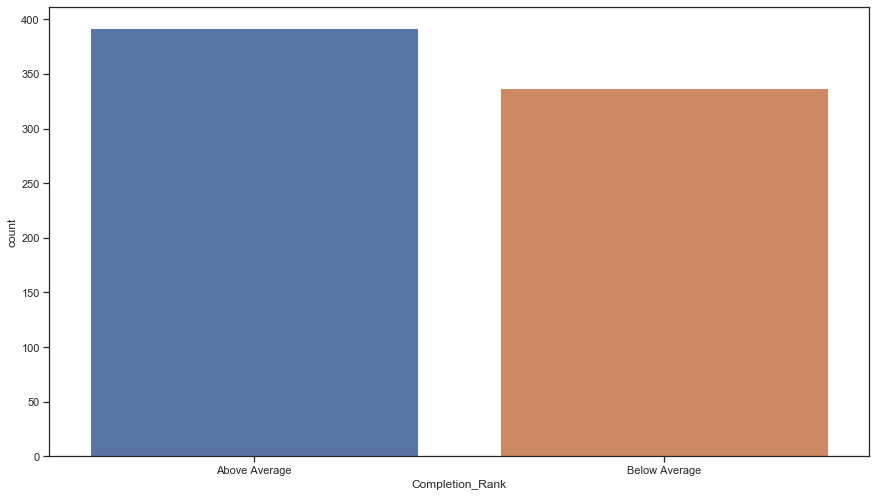

```python
# Check to see where QB's fall in terms of Completion Rank

plt.figure(figsize=[14.70,8.27])
sb.countplot(x='Completion_Rank', data = career_stats_qb_clean_new);
```

#### From this graph we see that more QB's fall into the above average group then the below average group. This grouping is skewed towards above average which means that the QBs that are below average are far below it.

#### Next lets plot all of our remaining variables against Rating/game to see if we notice anything interesting

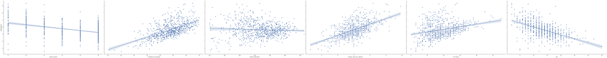

```python
# Scatterplots with Linear Regression lines
sb.pairplot(career_stats_qb_clean_new, y_vars = ['Ratings/game'], x_vars = ['Games_Played', 'Completion_Percentage', 'Passes_Attempted', 'Passing_Yards_Per_Attempt', 'TD_Passes', 'Ints'], kind="reg", height = 8.27,  aspect = 14.70/8.27);
plt.show();
```

#### Looking at the above graphs we see that completion percentage and passing yards per attempt show the strongest coorelation with Ratings/game

```python
career_stats_qb_clean_new.corr()
```

|  | Games_Played | Passes_Attempted | Completion_Percentage | Passing_Yards_Per_Attempt | TD_Passes | Ints | Ratings/game |
| --- | --- | --- | --- | --- | --- | --- | --- |
| Games_Played | 1.000000 | 0.679380 | 0.250431 | 0.174759 | 0.536039 | 0.297462 | -0.445750 |
| Passes_Attempted | 0.679380 | 1.000000 | 0.508488 | 0.225563 | 0.749383 | 0.387569 | -0.056453 |
| Completion_Percentage | 0.250431 | 0.508488 | 1.000000 | 0.570537 | 0.583828 | -0.187319 | 0.600108 |
| Passing_Yards_Per_Attempt | 0.174759 | 0.225563 | 0.570537 | 1.000000 | 0.575212 | -0.121465 | 0.585822 |
| TD_Passes | 0.536039 | 0.749383 | 0.583828 | 0.575212 | 1.000000 | 0.151530 | 0.299564 |
| Ints | 0.297462 | 0.387569 | -0.187319 | -0.121465 | 0.151530 | 1.000000 | -0.549447 |
| Ratings/game | -0.445750 | -0.056453 | 0.600108 | 0.585822 | 0.299564 | -0.549447 | 1.000000 |

#### I want to look at some of the earlier graphs that we considered while now accounting for completion rank

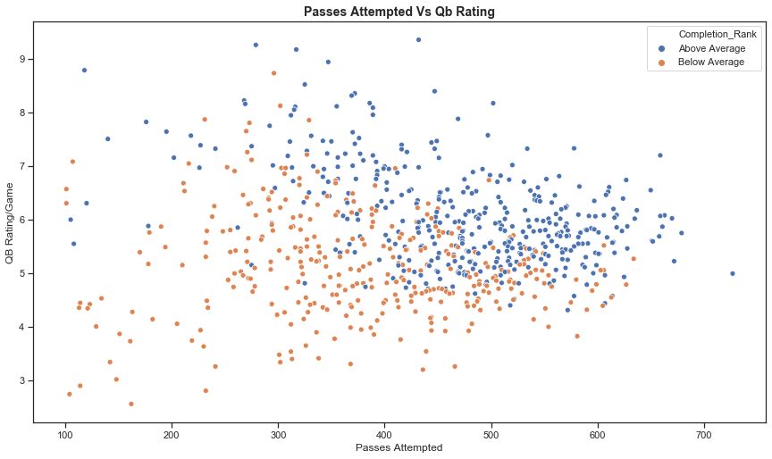

```python
# Scatterplot -  Ratings/game vs Passes Attempted with completion rank

plt.figure(figsize=[14.70, 8.27])
sb.scatterplot(data = career_stats_qb_clean_new, x = 'Passes_Attempted', y = 'Ratings/game', hue = 'Completion_Rank');
plt.xlabel("Passes Attempted")
plt.ylabel("QB Rating/Game");
plt.title("Passes Attempted Vs QB Rating".title(), fontsize = 14, weight = "bold" );
```

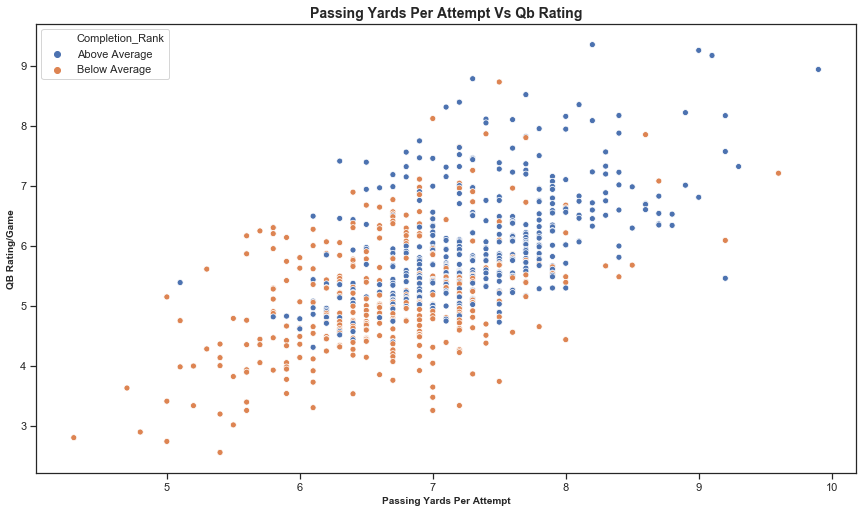

```python
# Scatterplot Ratings per game vs Passing Yards per Attempt with Completion Rank

plt.figure(figsize=[14.70, 8.27])
sb.scatterplot(data = career_stats_qb_clean_new, x = 'Passing_Yards_Per_Attempt', y = 'Ratings/game', hue = 'Completion_Rank');
plt.xlabel("Passing Yards Per Attempt", fontsize = 10, weight = "bold");
plt.ylabel("QB Rating/Game", fontsize = 10, weight = "bold");
plt.title("Passing Yards per Attempt Vs QB Rating".title(), fontsize = 14, weight = "bold" );
```

#### This graph was much more mixed then I expected it to be. While the blue does tend to be higher for QB's with higher passing yards per attempt it is no where near as pronounced as I originally expected. This show that even a below aveerage QB can have a good rating if they are throwing the ball down field more then average.

## Multivariate Exploration

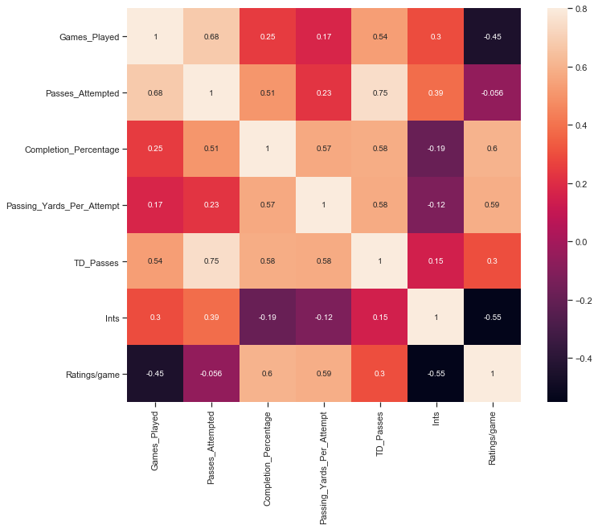

```python
corrmat = career_stats_qb_clean_new.corr()
f, ax = plt.subplots(figsize=(12, 9))
sb.heatmap(corrmat, vmax=.8, square=True, annot=True);
```

### Talk about some of the relationships you observed in this part of the investigation. Were there features that strengthened each other in terms of looking at your feature(s) of interest?

Looking at this heat map it is very clear to see the correlation between passing yards perattempt and QB rating, and also between completion percentage and QB rating.